# Static-II

Tommy Yu

October 14, 2017

```r
my_theme <- theme(plot.title=element_text(color="#014636", vjust=4, size=30, family="Imprint MT Shadow"),
                  plot.subtitle = element_text(color="#1a1a1a", vjust=4, size=20, family="Cambria"),
                  axis.title=element_text(color="#014636", size=24, family="Bookman Old Style"),
                  axis.text=element_text(color="#1a1a1a", size=18, family="Bookman Old Style"),
                  legend.title = element_text(color="#014636", size=18, family="Bookman Old Style"),
                  legend.text = element_text(color="#1a1a1a", size=18, family="Bookman Old Style"),
                  strip.text =  element_text(color="white", size=18, family="Bookman Old Style"),
                  strip.background = element_rect(fill="#762a83"),
                  plot.caption = element_text(color="#1a1a1a",size=15, vjust=-3, family="Bookman Old Style"),
                  plot.margin = margin(0.25, 0.25, 0.25, 0.25, "cm"))
```

## Graph 1

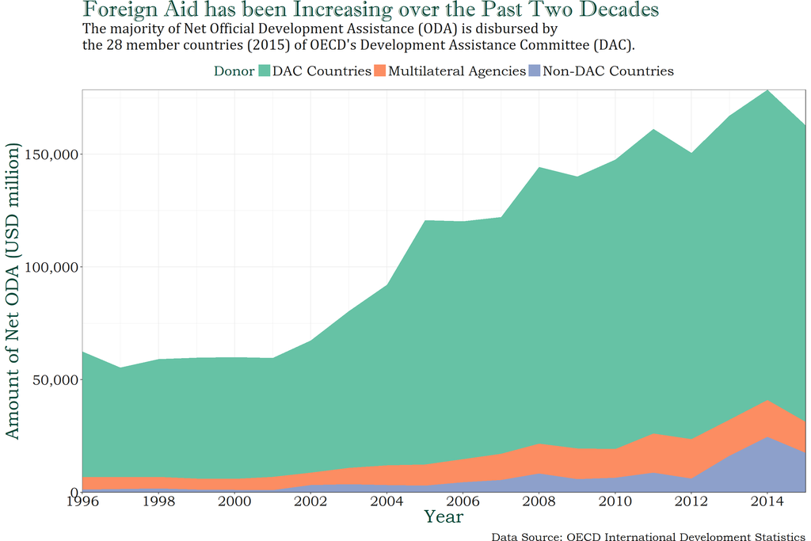

```r
df1 %>%
  ggplot(aes(x = Year, y = Amount, fill = Donor)) +
  geom_area(position = "stack") +
  scale_y_continuous(expand = c(0, 0), labels = scales::comma) +
  scale_x_continuous(expand = c(0, 0), breaks = (seq(1996,2015,2)), labels=(seq(1996,2015,2))) +
  scale_fill_manual(values = c("#66c2a5","#fc8d62","#8da0cb")) +
  labs(title = "Foreign Aid has been Increasing over the Past Two Decades",
       subtitle = "The majority of Net Official Development Assistance (ODA) is disbursed by\nthe 28 member countries (2015) of OECD's Development Assistance Committee (DAC).",
       caption = "Data Source: OECD International Development Statistics",
       x = "Year",
       y = "Amount of Net ODA (USD million)") +
  theme_bw()+
  my_theme+
  theme(legend.position = "top")
```

> This graph aims to show the trends in the scale of ODA over the past twenty years (1996-2015, since 2016 data is not fully available yet), as well as the difference in scale among DAC countries, non-DAC countries, and multilateral agencies. Despite the small decrease once every few years, there is an upward trend in total net ODA in general. It is also apparent that DAC members dominate the majority of foreign aid. It justifies that it is reasonable to focus on exploring foreign aid activities from DAC countries, since they can represent the full picture to a large extent, and their data are the most organized and comprehensive.

> *TO DO: Make sure the amount is measured in current USD. If so, it’d be better to convert all data into 2015 dollars.*

## Graph 2

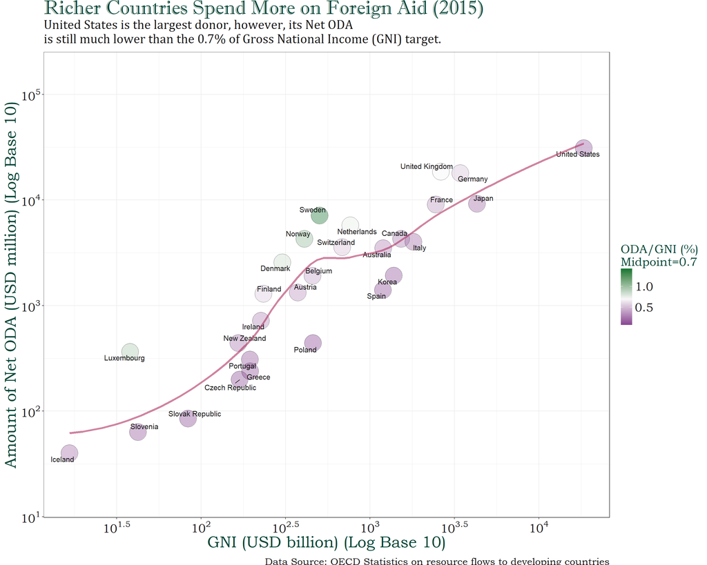

```r
df2 %>%
  ggplot(aes(x = GNI, y = ODA, color=`ODA/GNI`)) +
  geom_point(size=12, alpha=0.4)+
  geom_point(shape = 1,size = 12,colour = "black", alpha=0.5)+
  scale_y_log10(breaks = trans_breaks("log10", function(x) 10^x),
                labels = trans_format("log10", math_format(10^.x)))+
  scale_x_log10(breaks = trans_breaks("log10", function(x) 10^x),
                labels = trans_format("log10", math_format(10^.x)))+
  scale_colour_gradient2(low = "#762a83", mid = "#f7f7f7",
                         high = "#1b7837", midpoint = 0.7)+
  geom_text_repel(size=4, color="#1a1a1a",aes(label=Country))+
  geom_line(stat="smooth", method="loess", color="maroon", size=1.5, alpha=0.6)+
  theme_bw()+
  labs(title = "Richer Countries Spend More on Foreign Aid (2015)",
       subtitle = "United States is the largest donor, however, its Net ODA\nis still much lower than the 0.7% of Gross National Income (GNI) target. ",
       caption = "Data Source: OECD Statistics on resource flows to developing countries",
       x = "GNI (USD billion) (Log Base 10)",
       y = "Amount of Net ODA (USD million) (Log Base 10)",
       color = "ODA/GNI (%)\nMidpoint=0.7") +
  my_theme
```

> This is a remake of the graph from last time. Size of the circle is no longer used as an indicator of the level of ODA/GNI, due to the relatively narrow range of the ratio. It was hard for naked eyes to compare the size of two circles on the previous graph. Therefore, a gradient color scale is adopted to play the roles of both the size and the 2-color scale. The color white is set as the benchmark - the 0.7% globally recognized target, with green and purple on two sides of the scale. The positive correlation between GNI and ODA is obvious, as intution would suggest. However, despite being the absolute frontrunner in net ODA, USA is actually far from reaching the 0.7% target, as indicated by the darker purpule.

> *TO DO: If the graph is not on a log scale, it would make more sense to place a straight line that represents the 0.7% target. How to place such a benchmark on a log scale is what I need to figure out.*

## Graph 3

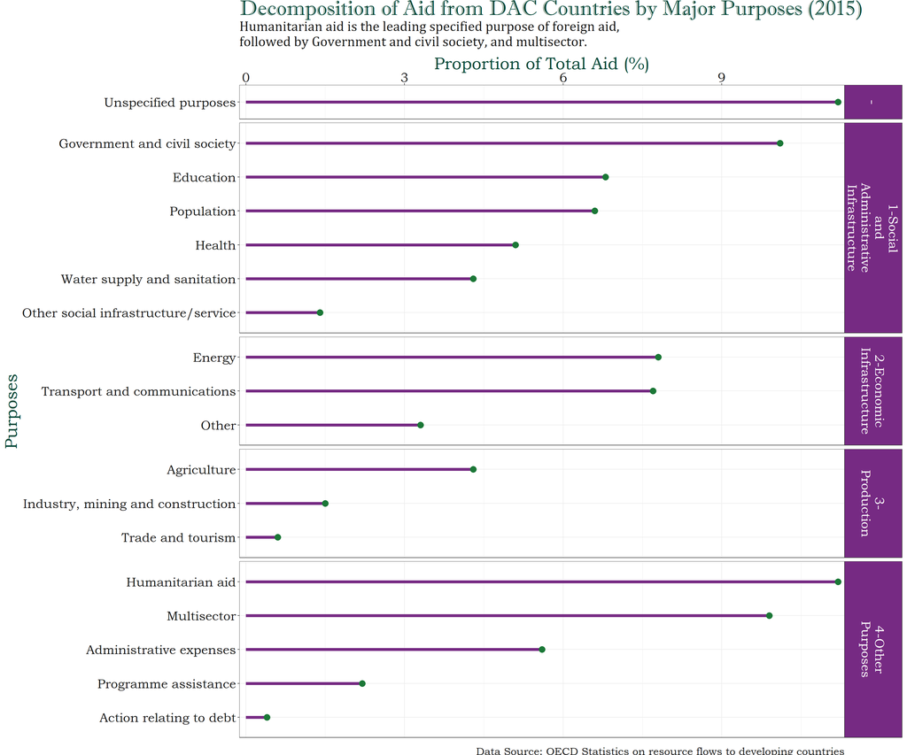

```r
df3 %>%
  mutate(Category=str_wrap(Category,10)) %>%
  ggplot(aes(x=Amount, y=reorder(Name, Amount)))+
  geom_segment(aes(xend=0, yend=Name), size=2, color="#762a83")+
  geom_point(size=4, color="#1b7837")+
  facet_grid(Category~., scales="free_y", space="free_y")+
  scale_x_continuous(position = "top", expand=c(0.01,0.01)) +
  labs(title="Decomposition of Aid from DAC Countries by Major Purposes (2015)",
       subtitle="Humanitarian aid is the leading specified purpose of foreign aid,\nfollowed by Government and civil society, and multisector.",
       x="Proportion of Total Aid (%)",
       y="Purposes",
       caption = "Data Source: OECD Statistics on resource flows to developing countries")+
  theme_bw()+
  my_theme
```

> This is also the remake of a previous chart with different data. Last time, I only looked at US foreign aid. However, ODA, as defined by OECD, excludes military purposes, while the data from US foreign aid do. I think it makes more sense to explore the aids by sector from the world’s level before looking at a specific donor. The graph simply serves as a quick reference for the proportion of each purpose under the 4 different categories.

## Graph 4

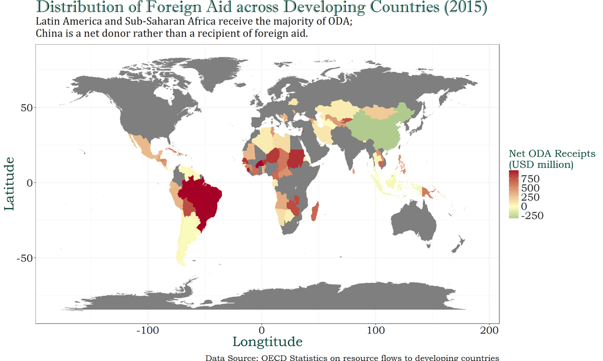

```r
map.world %>%
  left_join(df4, by=c("region"="Country")) %>%
  ggplot() +
  geom_map(map=map.world, aes(map_id=region, x=long, y=lat, fill=Amount))+
  scale_fill_gradient2(low = "#006837", mid = "#ffffbf",
                       high = "#a50026", midpoint = 0) +
  labs(title="Distribution of Foreign Aid across Developing Countries (2015)",
       subtitle="Latin America and Sub-Saharan Africa receive the majority of ODA;\nChina is a net donor rather than a recipient of foreign aid.",
       x="Longtitude",
       y="Latitude",
       fill="Net ODA Receipts\n(USD million)",
       caption = "Data Source: OECD Statistics on resource flows to developing countries") +
  theme_bw()+
  my_theme
```

> This map aims to show the geographical locations of aid receiving countries, as well as how much aid each of them receives. It serves as the first step to figure out what kind of countries receive the most aid. ODA receipts are total net ODA flows from DAC countries, multilateral organisations, and non-DAC countries.

> *TO DO: Apparently, some countries are missing! It’s due to the difference in country encoding between the aid data and the rworldmap package. I only had time to correct most of the spelling/naming discrepency, however, the hard part is to deal with the fact that some aid data are for >= 2 countries combined. Any advice?*